# California Groundwater Projections

Laurel Wee

11/24/2020

Dear Senator Meyer,

It is good to hear that you are interested in learning more about statewide groundwater resource depletion. California has enough water now in 2020, but it is important to look ahead as this vital natural resource continues to be in increasing demand. This demand is due to California’s growth and the depleting groundwater stock. Below you will find a data analysis along with figures that show models of California’s projected annual changes in groundwater stocks and three scenarios for when California will hit a depleted stock.

As seen in Figure 1, as time progresses demand for groundwater (Water Out) is greater than the amount of water going in (Water In) to the stock. This is leading to an overall decrease in groundwater availability over time (Annual Change). This model shows a net annual 232x10^6 m^3 decrease of water per year from the baseline stock. The rate of change was used to predict how much water will remain in 2050.

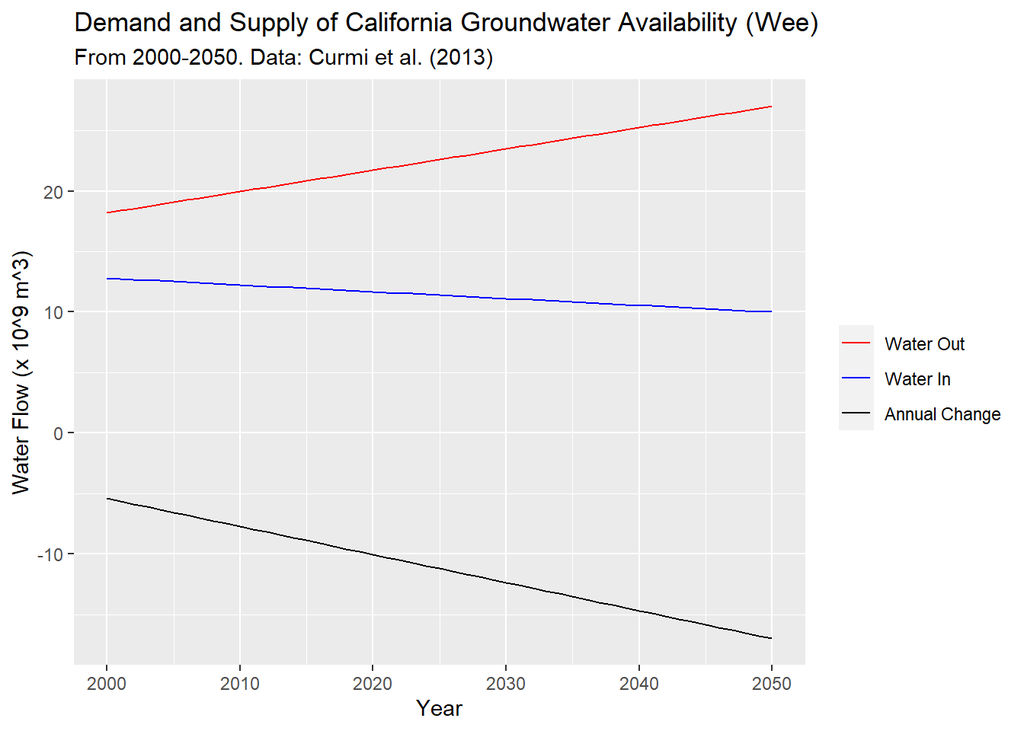

**Figure 1:** Model of the California groundwater projected flows in, out, and overall change between 2000-2050 using a Business as Usual scenario (BAU). The net annual change (black line) is negative due to the water withdraw going out (red line) of the stocks is greater than the recharge of water going in (blue line) to the stock . Data: Curmi et al. (2013).

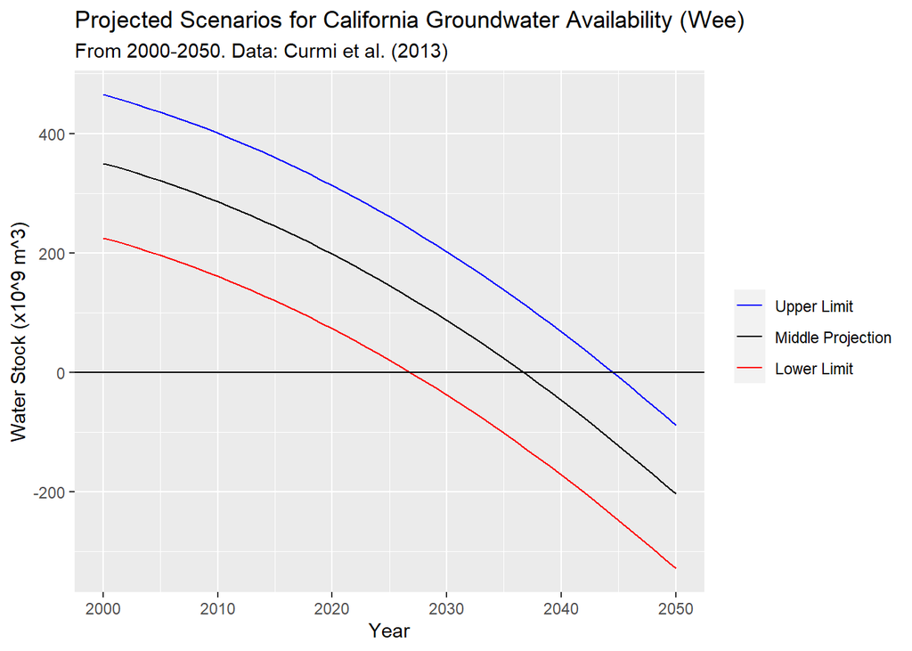

**Figure 2:** Model of projected ground water stocks from 2000-2050. Using expected 2000 resource value of 350x10^9 m^3 with a standard deviation of 115x10^9 m^3 and a confidence interval of 90. Upper (blue line) and lower (red line) limits are the scenarios one standard deviation from the mean (black line) projection value. The point at which the respective lines cross the y-axis, represents the year California will deplete the groundwater stock. The lower limit, mean, and upper limit show depletion at 2026, 236, and 2044 respectively.

Sincerely, Laurel Wee